# Covid Data analysis

Hamza Snoussi

2021-05-08

## Overview

This report is made using functions from an R program that loads the most recent data of Covid-19 and produces graphic plots to perform analysis. In this report we will be comparing distribution of new cases over time for the United States to the north African countries : Tunisia,Algeria,Libya,Morocco and Mauritania.

## Make plot :

the makePlot function takes a country name as the first argument and a variable name for the second parameter and produces a ggplot2 scatter plot of the given parameters (default value for variable name is new_cases).

Example:

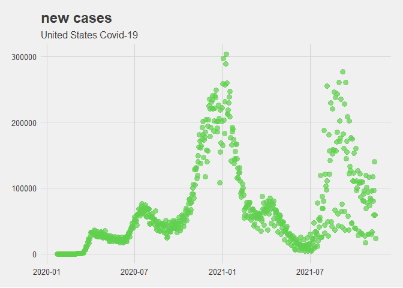

```r
makePlot(country = "United States" , variable = "new_cases")
```

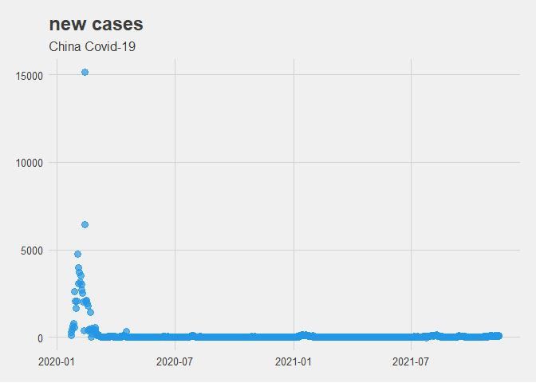

```r
makePlot("China")
```

## Compare Plot :

this function can take a vector (array) of countries and a variable name and produces a scatter plot, the function could take a third argument for facets representation, for example :

- comparing new_cases in Tunisia to new_cases in the United States with facets :

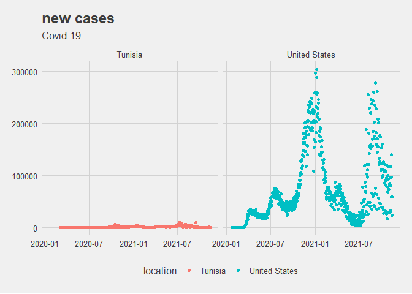

```r
comparePlots(c("Tunisia", "United States"),"new_cases",facets = TRUE)
```

- comparing new_cases in Tunisia to new_cases in the United States without facets :

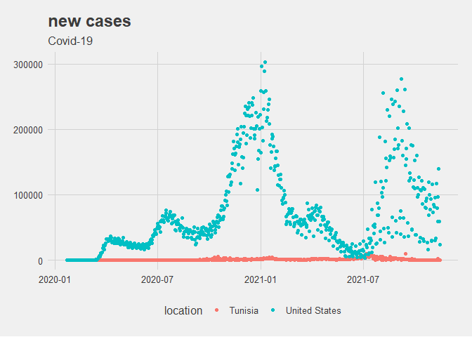

```r
comparePlots(c("Tunisia", "United States"),"new_cases",facets = FALSE)
```

to better approach the comparison, we will use the new cases per million metric in order to scale the results for a better interpretation of the pandemic waves.

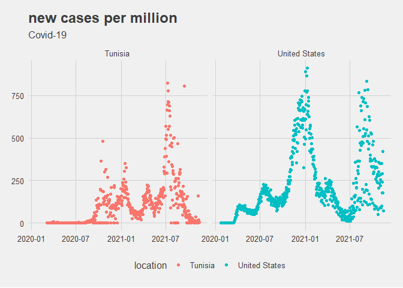

```r
comparePlots(c("Tunisia", "United States"),"new_cases_per_million")
```

we want to do the same thing for the 5 north African countries and compare the pandemic situation over the time :

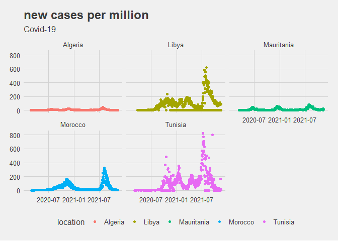

```r
comparePlots(c("Tunisia", "Algeria" , "Libya" , "Morocco" , "Mauritania"),"new_cases_per_million")
```

# Distinguish from :

as it’s name says, this function distinguish graphically the variable distribution of a country from a given continent.

Example (Tunisia ~ Africa) :

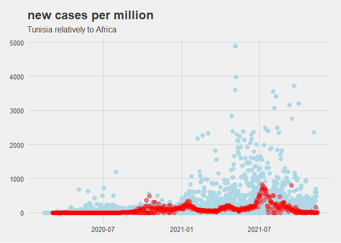

```r
 distinguishFrom(country = "Tunisia",continent = "Africa",variable = "new_cases_per_million")
```

# Credit

- R :

R Core Team (2021). R: A language and environment for statistical computing. R Foundation for Statistical Computing, Vienna, Austria. URL https://www.R-project.org/.

- ggplot2 :

Wickham H (2016). ggplot2: Elegant Graphics for Data Analysis. Springer-Verlag New York. ISBN 978-3-319-24277-4, https://ggplot2.tidyverse.org.